## Źródło danych

https://comtrade.un.org/data/

Analizę przeprowadzono na podstawie danych dotyczących eksportu między Polską i państwami z nią graniczącymi, a pozostałymi krajami. Dane zostały przygotowane przez United Nations (ONZ) i dotyczą roku 2018 zawierając (po wstępnym przetworzeniu przy użyciu programu CSVed) kolejno: państwo eksportujące, państwo importujące, sumaryczny koszt transakcji podany w US$.

```python
import tabulate
import pandas as pd
fileName = "data.csv"
data = pd.read_csv(fileName, sep = ',', usecols= [0,1,2])

data.head()
```

|  | Reporter | Partner | Trade Value (US$) |
| --- | --- | --- | --- |
| 0 | Poland | Afghanistan | 9596572 |
| 1 | Poland | Albania | 66487707 |
| 2 | Poland | Antarctica | 499190 |
| 3 | Poland | Algeria | 376354867 |
| 4 | Poland | American Samoa | 2404 |

## Utworzenie grafu

```python
import networkx as nx

g=nx.from_pandas_edgelist(data,
                          source='Reporter',
                          target='Partner',
                          edge_attr='Trade Value (US$)',
                          create_using=nx.Graph())
```

## Analiza grafu

```python
print(f'Liczba wierzchołków: {g.number_of_nodes()}')
print(f'Liczba krawędzi: {g.number_of_edges()}')
print(f'Gęstość: {nx.density(g)}')
print(f'Średnica: {nx.diameter(g)}')
print(f'Liczba węzłów: {g.order()}')
print(f'Rozmiar: {g.size()}')
```

```
Liczba wierzchołków: 230
Liczba krawędzi: 1570
Gęstość: 0.059616479969622174
Średnica: 3
Liczba węzłów: 230
Rozmiar: 1570
```

```python
import matplotlib.pyplot as plt
import warnings
warnings.filterwarnings('ignore')

degree = dict(g.degree(weight='Trade Value (US$)'))
sorted_degree = {r: degree[r] for r in sorted(degree, key=degree.get)}

plt.figure(figsize=(5, 10))
plt.barh(list(sorted_degree.keys()), sorted_degree.values())
plt.show()
```

[output not shown]

Wyznaczamy stopień centralności dla każdego z wierzchołków. Aby wykres był czytelny, pod uwagę wzięto jedynie pierwszych 20 węzłów z największym stopniem. Oczywiście dane opisują eksport z Polski i państw z nią graniczących, dlatego dla nich stopień będzie największy. Widać natomiast, że naszym najbliższym sąsiedztwie niemiecki eksport jest największy, jednak tuż za nimi jest Polska.

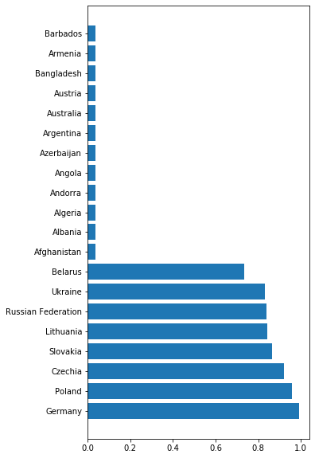

```python
degree_centrality = dict(nx.degree_centrality(g))
sorted_degree_centrality = {r: degree_centrality[r] for r in sorted(degree_centrality, key=degree_centrality.get, reverse = True)[:20]}

plt.figure(figsize=(5, 10))
plt.barh(list(sorted_degree_centrality.keys()), sorted_degree_centrality.values())
plt.show()
```

Sprawdzamy jak ważne dla (sieci) eksportu z okolicznego regionu są poszczególne węzły (państwa) za pomocą miary centralności przechodniości.

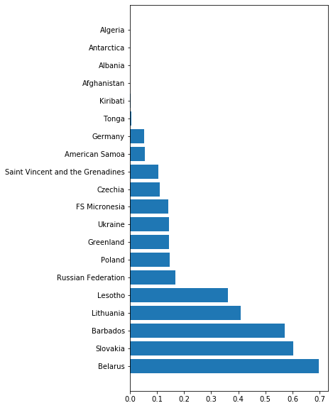

```python
betweenness_centrality = dict(nx.betweenness_centrality(g, weight='Trade Value (US$)'))
sorted_betweenness_centrality = {r: betweenness_centrality[r] for r in sorted(betweenness_centrality, key=betweenness_centrality.get, reverse = True)[:20]}

plt.figure(figsize=(5, 10))
plt.barh(list(sorted_betweenness_centrality.keys()), sorted_betweenness_centrality.values())
plt.show()
```

Wyznaczenie współczynnika grupowania, który jest miarą stopnia, w jakim węzły wykazują tendencję do skupiania się

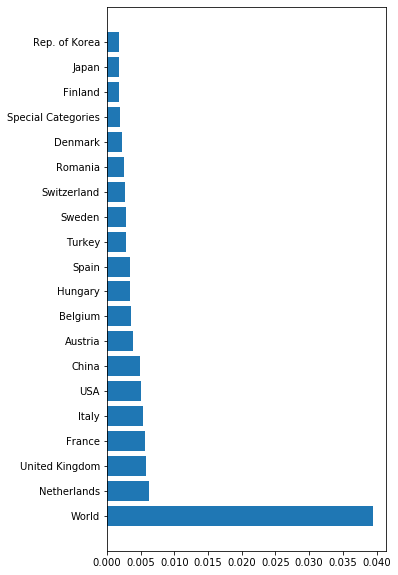

```python
clustering_coefficient = nx.clustering(g, weight='Trade Value (US$)')
sorted_clustering_coefficient = {r: clustering_coefficient[r] for r in sorted(clustering_coefficient, key=clustering_coefficient.get, reverse = True)[:20]}

plt.figure(figsize=(5, 10))
plt.barh(list(sorted_clustering_coefficient.keys()), sorted_clustering_coefficient.values())
plt.show()
```

Miara centralności bliskości mówi o tym, jak ważną rolę w grafie odgrywa dany wierzchołek. W tym przypadku mowa o tym, jak ważną rolę pełni w przepływie pieniędzy płynących z okolicznego eksportu. Mierzy się ją jako średnią odległość do wszystkich pozostałych węzłów.

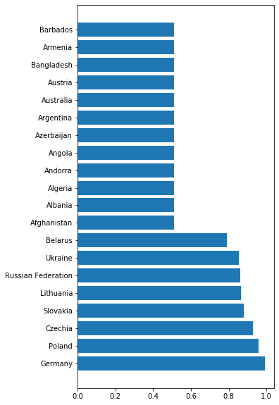

```python
closeness_centrality = dict(nx.closeness_centrality(g))
sorted_closeness_centrality = {r: closeness_centrality[r] for r in sorted(closeness_centrality, key=closeness_centrality.get, reverse = True)[:20]}

plt.figure(figsize=(5, 10))
plt.barh(list(sorted_closeness_centrality.keys()), sorted_closeness_centrality.values())
plt.show()
```

Miara PageRank pzostała zaprojektowana przez założycieli przedsiębiorstwa Google i nazwana nazwiskiem jednego z nich. PageRank jest rozwinięciem znanej od dawna heurystyki, wedle której jakość węzła jest proporcjonalna do liczby węzłów z nim powiązanych.

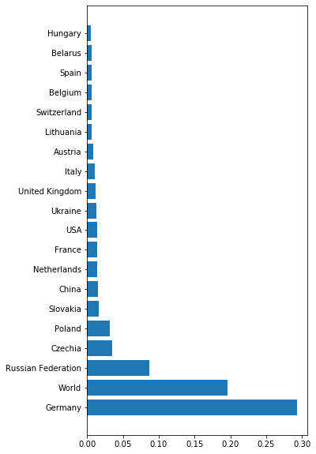

```python
pagerank = dict(nx.pagerank(g, weight='Trade Value (US$)'))
sorted_pagerank = {r: pagerank[r] for r in sorted(pagerank, key=pagerank.get, reverse = True)[:20]}

plt.figure(figsize=(5, 10))
plt.barh(list(sorted_pagerank.keys()), sorted_pagerank.values())
plt.show()
```

## Wizualizacja grafu

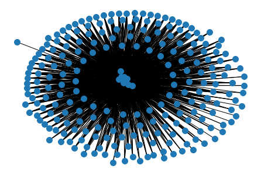

```python
nx.draw_kamada_kawai(g, node_size=100, weight='Trade Value (US$)')
```

Kraje pełniące najważniejszą rolę w eksporcie z okolicznego regionu (których udział w tym procesie przewyższa średnią).

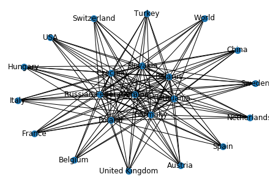

```python
degrees = dict(g.degree(weight='Trade Value (US$)')).values()
avg = sum(degrees) / len(degrees)

selected_nodes = {k: v for k, v in dict(g.degree(weight='Trade Value (US$)')).items() if v > avg}
subgraph = g.subgraph(selected_nodes)
nx.draw_kamada_kawai(subgraph, node_size=100, with_labels=True, label_color='r', weight='Trade Value (US$)')
```

Stosunek krawędzi do węzłów - możliwy eksport towarów do pozostałych krajów

```python
countries = dict(g.degree(weight='Trade Value (US$)')).keys()
countries_ordered = sorted(countries)

datas = []

for key in countries_ordered:
    data = {}
    data['Kraj'] = key
    data['Liczba partnerów'] = len(g.edges(key))
    edges = [tuple[1] for tuple in list(g.edges(key))]
    data['Lista partnerów'] = '\n'.join(sorted(edges))
    datas.append(data)

sorted_datas = sorted(datas, key=lambda x:x['Liczba partnerów'], reverse=True)

import tabulate

print("Pierwsze 8 (interesuje nas jedynie Polska i  kraje graniczące - pozostałe zawsze będą mieć liczbę krawędzi <= 8)")
header = ['Kraj', 'Liczba partnerów','Lista partnerów']
rows =  [x.values() for x in sorted_datas[:8]]
print(tabulate.tabulate(rows, header, "fancy_grid"))
print('...')
```

```
Pierwsze 8 (interesuje nas jedynie Polska i  kraje graniczące - pozostałe zawsze będą mieć liczbę krawędzi <= 8)
╒════════════════════╤════════════════════╤══════════════════════════════════════╕
│ Kraj               │   Liczba partnerów │ Lista partnerów                      │
╞════════════════════╪════════════════════╪══════════════════════════════════════╡
│ Germany            │                227 │ Afghanistan                          │
│                    │                    │ Albania                              │
│                    │                    │ Algeria                              │
│                    │                    │ American Samoa                       │
│                    │                    │ Andorra                              │
│                    │                    │ Angola                               │
│                    │                    │ Anguilla                             │
│                    │                    │ Antarctica                           │
│                    │                    │ Antigua and Barbuda                  │
│                    │                    │ Argentina                            │
│                    │                    │ Armenia                              │
│                    │                    │ Aruba                                │
│                    │                    │ Australia                            │
│                    │                    │ Austria                              │
│                    │                    │ Azerbaijan                           │
│                    │                    │ Bahamas                              │
│                    │                    │ Bangladesh                           │
│                    │                    │ Barbados                             │
│                    │                    │ Belarus                              │
│                    │                    │ Belgium                              │
│                    │                    │ Belize                               │
│                    │                    │ Benin                                │
│                    │                    │ Bermuda                              │
│                    │                    │ Bhutan                               │
│                    │                    │ Bolivia (Plurinational State of)     │
│                    │                    │ Bonaire                              │
│                    │                    │ Bosnia Herzegovina                   │
│                    │                    │ Botswana                             │
│                    │                    │ Bouvet Island                        │
│                    │                    │ Br. Virgin Isds                      │
│                    │                    │ Brazil                               │
│                    │                    │ Brunei Darussalam                    │
│                    │                    │ Bulgaria                             │
│                    │                    │ Bunkers                              │
│                    │                    │ Burkina Faso                         │
│                    │                    │ Burundi                              │
```

[output cut: 1556 more lines]

```
│                    │                    │ Uganda                               │
│                    │                    │ Ukraine                              │
│                    │                    │ United Arab Emirates                 │
│                    │                    │ United Kingdom                       │
│                    │                    │ United Rep. of Tanzania              │
│                    │                    │ Uruguay                              │
│                    │                    │ Uzbekistan                           │
│                    │                    │ Venezuela                            │
│                    │                    │ Viet Nam                             │
│                    │                    │ World                                │
│                    │                    │ Yemen                                │
│                    │                    │ Zambia                               │
│                    │                    │ Zimbabwe                             │
╘════════════════════╧════════════════════╧══════════════════════════════════════╛
...
```

# Pytania biznesowe

### 1. Który z krajów jest największym eksporterem w okolicznym dla Polski regionie?

Wcześniejsza analiza wykazała, że największą liczbę partnerów oraz największe zyski z eksportu zarabiają Niemcy

### 3. Rola którego z krajów biorących udział w przepływie pieniędzy wygenerowanych z okolicznego eksportu jest największa?

Odpowiedź na to pytanie dostarcza nam miara centralności przechodniości (betweenness centrality), która opisuje wpływ konkretnego wierzchołka na dyfuzję informacji w grafie. Tym krajem jest Białoruś.